# Proyecto Final — Econometría Financiera

```r
summary(res_5m[["WMT"]]$fit)
```

```
## Series: lp
## ARIMA(4,1,2)
##
## Coefficients:
##          ar1      ar2      ar3     ar4      ma1     ma2
##       0.0403  -0.3914  -0.0039  0.0626  -0.0825  0.4290
## s.e.  0.2559   0.2437   0.0210  0.0152   0.2563  0.2506
##
## sigma^2 = 0.000004232:  log likelihood = 21940.73
## AIC=-43867.47   AICc=-43867.45   BIC=-43822.43
##
## Training set error measures:
##                         ME        RMSE          MAE          MPE       MAPE
## Training set 0.00002052848 0.002055666 0.0009374332 0.0004185934 0.01987624
##                  MASE          ACF1
## Training set 1.000777 -0.0005786837
```

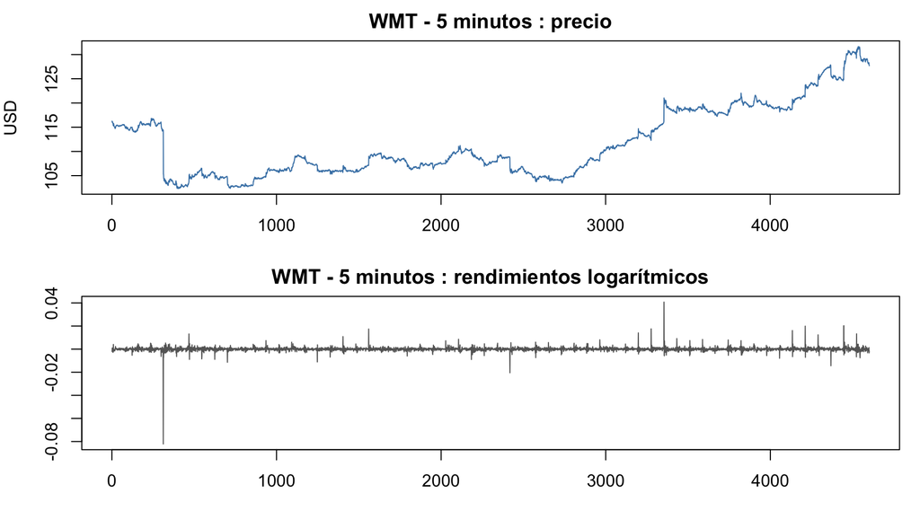

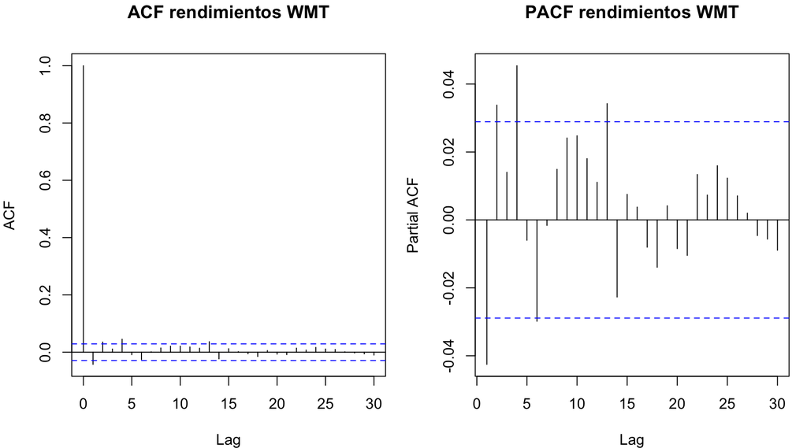

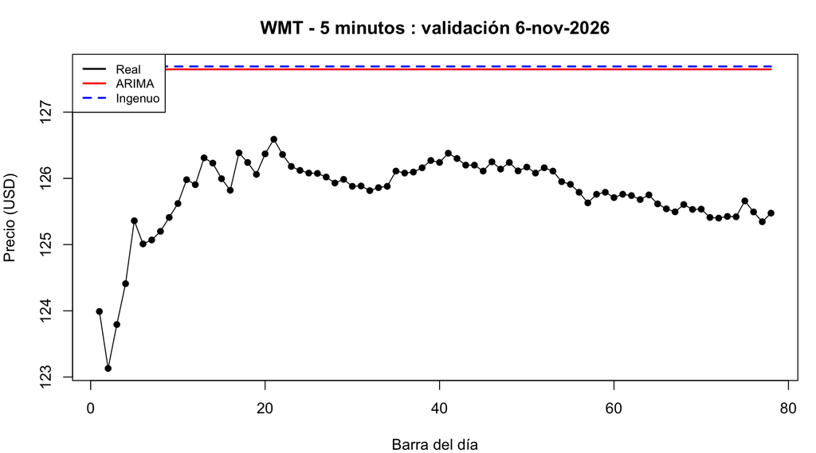

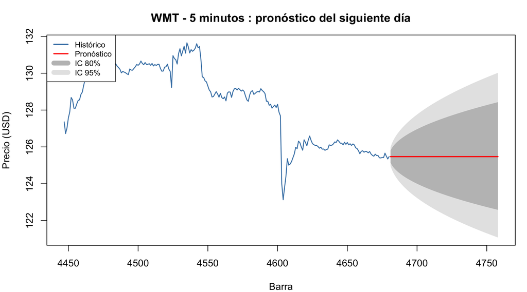

```r
graficar(res_5m, "WMT", "5 minutos")
```

**Interpretación:** En 1 hora el modelo es una caminata aleatoria con deriva, pero Ljung-Box rechaza ruido blanco (p = 0.012): queda algo de estructura sin capturar, y el ingenuo le gana en la validación. En 5 minutos el modelo es ARIMA(4,1,2), más complejo, y sí le gana al ingenuo (RMSE de 1.95 contra 2.00), con residuales de ruido blanco (p = 0.147). Esto sugiere que en WMT hay patrones de muy corto plazo que solo se observan en alta frecuencia.

## 4.8 Pronóstico del siguiente día de operación

Precio esperado al cierre del siguiente día (última barra pronosticada) con su intervalo de confianza al 95%, junto con el último precio observado.

```r
tabla_pron <- function(res) {
  do.call(rbind, lapply(names(res), function(s) {
    p <- res[[s]]$pron
    k <- length(p$mean)
    data.frame(Accion        = s,
               Ultimo_precio = round(tail(res[[s]]$prueba$cierre, 1), 2),
               Pronostico    = round(exp(p$mean[k]), 2),
               IC95_inferior = round(exp(p$lower[k, 2]), 2),
               IC95_superior = round(exp(p$upper[k, 2]), 2),
               Cambio_pct    = round(100 * (exp(p$mean[k]) /
                                 tail(res[[s]]$prueba$cierre, 1) - 1), 2))
  }))
}
kable(tabla_pron(res_1h), row.names = FALSE,
      caption = "Pronóstico al cierre del siguiente día — modelo de 1 hora")
```

Pronóstico al cierre del siguiente día — modelo de 1 hora

| Accion | Ultimo_precio | Pronostico | IC95_inferior | IC95_superior | Cambio_pct |
| --- | --- | --- | --- | --- | --- |
| NVDA | 186.68 | 187.05 | 176.83 | 197.85 | 0.20 |
| MSFT | 530.55 | 530.55 | 512.99 | 548.71 | 0.00 |
| AAPL | 342.36 | 342.36 | 330.85 | 354.28 | 0.00 |
| AVGO | 293.33 | 293.33 | 276.10 | 311.63 | 0.00 |
| AMD | 449.03 | 449.03 | 416.85 | 483.69 | 0.00 |
| JPM | 334.49 | 334.84 | 324.95 | 345.02 | 0.10 |
| WMT | 125.47 | 125.63 | 122.07 | 129.30 | 0.13 |
| XOM | 165.89 | 165.90 | 161.02 | 170.93 | 0.01 |
| V | 422.73 | 422.73 | 411.96 | 433.78 | 0.00 |
| JNJ | 276.26 | 276.48 | 269.97 | 283.15 | 0.08 |

```r
kable(tabla_pron(res_5m), row.names = FALSE,
      caption = "Pronóstico al cierre del siguiente día — modelo de 5 minutos")
```

Pronóstico al cierre del siguiente día — modelo de 5 minutos

| Accion | Ultimo_precio | Pronostico | IC95_inferior | IC95_superior | Cambio_pct |
| --- | --- | --- | --- | --- | --- |
| NVDA | 186.68 | 186.04 | 177.31 | 195.19 | -0.34 |
| MSFT | 530.55 | 530.55 | 513.40 | 548.28 | 0.00 |
| AAPL | 342.36 | 342.36 | 331.82 | 353.25 | 0.00 |
| AVGO | 293.33 | 291.67 | 276.83 | 307.30 | -0.57 |
| AMD | 449.03 | 448.93 | 414.25 | 486.52 | -0.02 |
| JPM | 334.49 | 334.49 | 325.46 | 343.77 | 0.00 |
| WMT | 125.47 | 125.47 | 121.08 | 130.02 | 0.00 |
| XOM | 165.89 | 165.89 | 160.56 | 171.40 | 0.00 |
| V | 422.73 | 423.77 | 414.44 | 433.31 | 0.25 |
| JNJ | 276.26 | 276.22 | 267.32 | 285.42 | -0.01 |

**Interpretación:** Los pronósticos para el lunes 9 de noviembre son prácticamente planos: el cambio esperado va de −0.57% (AVGO, 5 minutos) a +0.25% (V, 5 minutos). Lo relevante son los intervalos de confianza al 95%, que son amplios: NVDA podría cerrar entre 177 y 198 USD y AMD entre 414 y 487 USD. Es decir, el modelo no anticipa dirección, pero sí cuantifica el rango de riesgo diario de cada acción.

## 4.9 Conclusión de la Parte 3

Los precios intradía de las 10 acciones se comportan esencialmente como caminatas aleatorias, lo que es consistente con la hipótesis de mercados eficientes en su forma débil: los precios pasados no permiten predecir los futuros de forma rentable. El ARIMA supera al modelo ingenuo en 9 de 20 casos, pero por márgenes de 1 a 5%, insuficientes para generar ganancias después de costos de operación. El valor práctico de estos modelos está en sus intervalos de confianza, que miden el riesgo de cada acción y sirven para fijar niveles de stop-loss. Como la varianza no es constante (choque del 5 de noviembre), la Parte 4 modela directamente la volatilidad con GARCH.

**Limitación:** las barras se tratan como consecutivas, aunque entre el cierre de un día y la apertura del siguiente hay un salto de horario (noches y fines de semana) en el que el precio puede moverse por noticias.

# 5 Parte 4. Volatilidad (GARCH) y estrategia de portafolio

## 5.1 Objetivo

Modelar la volatilidad de las 10 acciones con GARCH(1,1), pronosticar su riesgo de corto plazo y usar ese pronóstico para construir el portafolio objetivo en HowMarketsWorks con un enfoque de **paridad de riesgo**.

## 5.2 Paquetes y parámetros

```r
paquetes <- c("quantmod", "rugarch", "knitr")
faltan <- paquetes[!paquetes %in% installed.packages()[, "Package"]]
if (length(faltan) > 0) install.packages(faltan)

library(quantmod)   # descarga de Yahoo Finance
library(rugarch)    # modelos GARCH
library(knitr)      # tablas
```

Parámetros de la estrategia (tomados de la cuenta de HowMarketsWorks al 7-nov-2026):

```r
acciones <- c("NVDA", "MSFT", "AAPL", "AVGO", "AMD",
              "JPM", "WMT", "XOM", "V", "JNJ")

valor_portafolio <- 998634.78   # Portfolio Value en HowMarketsWorks
pct_invertir     <- 0.90        # porcentaje del portafolio que se invierte en acciones
peso_maximo      <- 0.20        # peso máximo por acción
comision         <- 10          # comisión por operación (USD)

# Posiciones actuales en HowMarketsWorks (número de acciones)
posiciones <- c(NVDA = 60, MSFT = 50, AAPL = 0, AVGO = 0, AMD = 0,
                JPM = 41, WMT = 163, XOM = 0, V = 0, JNJ = 0)
```

## 5.3 Datos

Mismo periodo que la Parte 1: rendimientos logarítmicos diarios del 3 de enero de 2023 al 6 de noviembre de 2026. Para el GARCH se expresan **en porcentaje** (multiplicados por 100), lo que mejora la estabilidad numérica de la estimación.

```r
inicio <- "2023-01-01"
fin    <- "2026-11-07"

bajar <- function(simbolo) {
  bajar_guardado(simbolo, inicio, fin)
}

precios <- NULL; cierres <- c()
for (s in acciones) {
  x <- bajar(s)
  p <- Ad(x); colnames(p) <- s
  precios <- if (is.null(precios)) p else merge(precios, p)
  cierres[s] <- as.numeric(tail(Cl(x), 1))   # último precio de cierre (sin ajustar)
}
spx <- Ad(bajar("^GSPC"))

rend    <- na.omit(diff(log(precios))) * 100   # rendimientos en %
rend_sp <- na.omit(diff(log(spx))) * 100
nrow(rend)
```

```
## [1] 965
```

## 5.4 ¿Hay efecto ARCH?

Antes de estimar un GARCH hay que comprobar que la volatilidad cambia en el tiempo. Se aplica la prueba Ljung-Box a los **rendimientos al cuadrado**:

- $H_0$: no hay autocorrelación en los rendimientos al cuadrado (la varianza es constante).
- $H_1$: hay autocorrelación (la volatilidad se agrupa: a días volátiles les siguen días volátiles).

```r
arch <- data.frame(
  Accion   = acciones,
  Q_stat   = sapply(acciones, function(s) round(Box.test(rend[, s]^2, lag = 10, type = "Ljung-Box")$statistic, 2)),
  p_valor  = sapply(acciones, function(s) signif(Box.test(rend[, s]^2, lag = 10, type = "Ljung-Box")$p.value, 3))
)
arch$Efecto_ARCH <- ifelse(arch$p_valor < 0.05, "Sí", "No")
kable(arch, row.names = FALSE, caption = "Ljung-Box sobre rendimientos al cuadrado (10 rezagos)")
```

Ljung-Box sobre rendimientos al cuadrado (10 rezagos)

| Accion | Q_stat | p_valor | Efecto_ARCH |
| --- | --- | --- | --- |
| NVDA | 11.52 | 0.3180000 | No |
| MSFT | 10.64 | 0.3860000 | No |
| AAPL | 162.88 | 0.0000000 | Sí |
| AVGO | 31.39 | 0.0005070 | Sí |
| AMD | 35.29 | 0.0001110 | Sí |
| JPM | 45.44 | 0.0000018 | Sí |
| WMT | 10.89 | 0.3670000 | No |
| XOM | 66.73 | 0.0000000 | Sí |
| V | 47.02 | 0.0000009 | Sí |
| JNJ | 18.04 | 0.0542000 | No |

**Interpretación:** La prueba Ljung-Box sobre rendimientos al cuadrado rechaza $H_0$ al 5% en 6 de 10 acciones (AAPL, AVGO, AMD, JPM, XOM y V): en ellas la volatilidad se agrupa en el tiempo. En NVDA, MSFT, WMT y JNJ no se rechaza (JNJ apenas, p = 0.054). Sin embargo, esta prueba pierde potencia cuando hay saltos extremos aislados (por ejemplo, NVDA en mayo de 2023 y enero de 2025), que dominan los rendimientos al cuadrado. Como se ve en la siguiente sección, los parámetros α y β del GARCH son significativos en las 10 acciones, lo que sí confirma volatilidad cambiante en todas.

## 5.5 Modelos GARCH(1,1)

$$r_t = \mu + \varepsilon_t, \qquad
\varepsilon_t = \sigma_t z_t$$
$$\sigma_t^2 = \omega + \alpha \,
\varepsilon_{t-1}^2 + \beta \, \sigma_{t-1}^2$$

- $\alpha$: qué tanto reacciona la volatilidad a un choque reciente.
- $\beta$: qué tanto se “arrastra” la volatilidad de días anteriores.
- $\alpha + \beta$ (**persistencia**): cerca de 1 significa que los choques de volatilidad tardan mucho en disiparse.
- **Vida media:** días que tarda un choque en reducirse a la mitad.

Se estima con distribución **t-Student**, porque los residuales de la Parte 1 mostraron colas pesadas, y se compara con la distribución normal mediante el criterio AIC (menor es mejor).

```r
spec_t <- ugarchspec(variance.model = list(model = "sGARCH", garchOrder = c(1, 1)),
                     mean.model     = list(armaOrder = c(0, 0), include.mean = TRUE),
                     distribution.model = "std")
spec_n <- ugarchspec(variance.model = list(model = "sGARCH", garchOrder = c(1, 1)),
                     mean.model     = list(armaOrder = c(0, 0), include.mean = TRUE),
                     distribution.model = "norm")

ajustes <- list(); tabla_garch <- data.frame()
for (s in acciones) {
  ft <- ugarchfit(spec_t, data = rend[, s], solver = "hybrid")
  fn <- ugarchfit(spec_n, data = rend[, s], solver = "hybrid")
  fc <- ugarchforecast(ft, n.ahead = 10)
  ajustes[[s]] <- ft
  cf <- coef(ft)
  lb <- Box.test(residuals(ft, standardize = TRUE)^2, lag = 10, type = "Ljung-Box")
  tabla_garch <- rbind(tabla_garch, data.frame(
    Accion        = s,
    omega         = round(cf["omega"], 4),
    alpha         = round(cf["alpha1"], 3),
    beta          = round(cf["beta1"], 3),
    Persistencia  = round(persistence(ft), 3),
    Vida_media_d  = round(halflife(ft), 1),
    gl_t          = round(cf["shape"], 1),
    AIC_t         = round(infocriteria(ft)[1], 3),
    AIC_normal    = round(infocriteria(fn)[1], 3),
    LB_resid2_p   = round(lb$p.value, 3),
    Vol_largo_pl  = round(sqrt(uncvariance(ft) * 252) / 100, 3),
    Vol_actual    = round(tail(sigma(ft), 1) * sqrt(252) / 100, 3),
    Vol_pron_10d  = round(sqrt(mean(sigma(fc)^2)) * sqrt(252) / 100, 3)
  ))
}
kable(tabla_garch, row.names = FALSE,
      caption = "GARCH(1,1) con distribución t-Student (volatilidades anualizadas)")
```

GARCH(1,1) con distribución t-Student (volatilidades anualizadas)

| Accion | omega | alpha | beta | Persistencia | Vida_media_d | gl_t | AIC_t | AIC_normal | LB_resid2_p | Vol_largo_pl | Vol_actual | Vol_pron_10d |
| --- | --- | --- | --- | --- | --- | --- | --- | --- | --- | --- | --- | --- |
| NVDA | 0.4560 | 0.060 | 0.885 | 0.945 | 12.3 | 5.5 | 4.862 | 4.988 | 0.999 | 0.457 | 0.566 | 0.533 |
| MSFT | 0.2388 | 0.083 | 0.829 | 0.911 | 7.5 | 4.4 | 3.641 | 3.806 | 1.000 | 0.261 | 0.403 | 0.345 |
| AAPL | 0.6745 | 0.119 | 0.624 | 0.743 | 2.3 | 3.8 | 3.558 | 3.694 | 0.114 | 0.257 | 0.333 | 0.272 |
| AVGO | 1.4346 | 0.116 | 0.730 | 0.846 | 4.2 | 3.7 | 4.746 | 4.944 | 0.972 | 0.485 | 0.753 | 0.591 |
| AMD | 0.0386 | 0.018 | 0.981 | 0.999 | 692.7 | 3.9 | 5.237 | 5.381 | 0.521 | 0.987 | 0.811 | 0.833 |
| JPM | 0.4553 | 0.123 | 0.668 | 0.791 | 3.0 | 3.8 | 3.347 | 3.532 | 0.967 | 0.234 | 0.366 | 0.276 |
| WMT | 0.0181 | 0.031 | 0.959 | 0.990 | 69.5 | 4.0 | 3.186 | 3.432 | 0.999 | 0.214 | 0.267 | 0.266 |
| XOM | 0.0630 | 0.035 | 0.938 | 0.973 | 25.1 | 8.6 | 3.622 | 3.641 | 0.095 | 0.241 | 0.297 | 0.286 |
| V | 0.0023 | 0.005 | 0.994 | 0.999 | 692.8 | 4.0 | 3.091 | 3.240 | 0.000 | 0.240 | 0.226 | 0.226 |
| JNJ | 0.0833 | 0.055 | 0.885 | 0.940 | 11.2 | 4.3 | 2.966 | 3.112 | 0.997 | 0.187 | 0.251 | 0.234 |

Columnas: `gl_t` son los grados de libertad de la t-Student (valores bajos = colas más pesadas); `LB_resid2_p` es el valor p de Ljung-Box sobre los residuales estandarizados al cuadrado ($H_0$: el GARCH ya capturó la dinámica de la volatilidad); `Vol_largo_pl` es la volatilidad de largo plazo a la que el modelo regresa; `Vol_actual` es la del último día y `Vol_pron_10d` el promedio pronosticado para los próximos 10 días.

```r
kable(data.frame(Accion = acciones,
                 Significativos_al_5pct = sapply(acciones, function(s) {
                   m <- ajustes[[s]]@fit$matcoef
                   paste(rownames(m)[m[, 4] < 0.05], collapse = ", ")
                 })),
      row.names = FALSE, caption = "Parámetros significativos al 5% en cada modelo")
```

Parámetros significativos al 5% en cada modelo

| Accion | Significativos_al_5pct |
| --- | --- |
| NVDA | mu, alpha1, beta1, shape |
| MSFT | mu, alpha1, beta1, shape |
| AAPL | mu, alpha1, beta1, shape |
| AVGO | omega, alpha1, beta1, shape |
| AMD | alpha1, beta1, shape |
| JPM | mu, omega, alpha1, beta1, shape |
| WMT | mu, omega, alpha1, beta1, shape |
| XOM | alpha1, beta1, shape |
| V | mu, alpha1, beta1, shape |
| JNJ | alpha1, beta1, shape |

**Interpretación:** En las 10 acciones α y β son significativos al 5%, al igual que el parámetro de forma de la t-Student. La distribución t-Student tiene menor AIC que la normal en todos los casos, lo que confirma colas pesadas (grados de libertad de 3.7 a 8.6). La persistencia va de 0.74 (AAPL, cuyos choques se reducen a la mitad en 2.3 días) a 0.99 o más en WMT, AMD y V, donde los choques tardan meses en disiparse. Ljung-Box sobre los residuales estandarizados al cuadrado no rechaza $H_0$ en 9 de 10 acciones, es decir, el GARCH capturó la dinámica de la volatilidad; la excepción es V (p = 0.000), cuyo modelo es poco confiable. Hoy la volatilidad actual supera a la de largo plazo en casi todas las acciones, reflejo del choque del 5 de noviembre.

## 5.6 Análisis a fondo: NVDA, JNJ y WMT

```r
graficar_vol <- function(s) {
  ft <- ajustes[[s]]
  vol <- sigma(ft) * sqrt(252) / 100
  par(mfrow = c(2, 1), mar = c(3, 4, 2, 1))
  plot(index(rend), abs(as.numeric(rend[, s])), type = "h", col = "grey60",
       main = paste(s, ": rendimiento absoluto diario (%)"), xlab = "", ylab = "%")
  plot(index(rend), as.numeric(vol), type = "l", col = "red", lwd = 1.5,
       main = paste(s, ": volatilidad condicional anualizada (GARCH)"), xlab = "", ylab = "")
  abline(h = sqrt(uncvariance(ft) * 252) / 100, lty = 2, col = "blue")
  legend("topright", c("Volatilidad GARCH", "Volatilidad de largo plazo"),
         col = c("red", "blue"), lty = c(1, 2), cex = 0.8)
  par(mfrow = c(1, 1))
}
```

### 5.6.1 NVDA

```r
ajustes[["NVDA"]]@fit$matcoef
```

```
##          Estimate  Std. Error   t value            Pr(>|t|)
## mu     0.26430160  0.08038333  3.288015 0.00100896491816638
## omega  0.45604997  0.25498111  1.788564 0.07368510646836124
## alpha1 0.06030225  0.02548985  2.365736 0.01799428174559070
## beta1  0.88470936  0.04927552 17.954340 0.00000000000000000
## shape  5.53347105  0.84881893  6.519024 0.00000000007076628
```

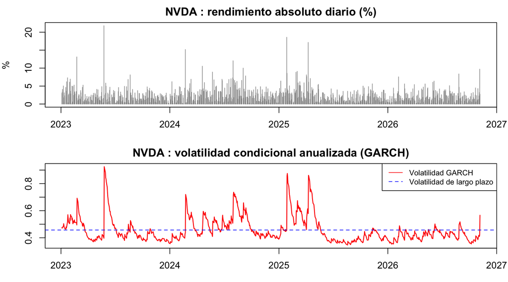

```r
graficar_vol("NVDA")
```

**Interpretación:** El rendimiento medio diario (μ = 0.26%) es significativo al 1%, consistente con su fuerte tendencia alcista en el periodo. β = 0.885 y α = 0.060 dan una persistencia de 0.945: un choque de volatilidad se reduce a la mitad en unos 12 días. Su volatilidad actual (57% anual) está por encima de su nivel de largo plazo (46%), y el modelo pronostica que bajará gradualmente (53% en 10 días). La t-Student con 5.5 grados de libertad confirma colas pesadas: los movimientos extremos son mucho más frecuentes de lo que supondría una distribución normal.

### 5.6.2 JNJ

```r
ajustes[["JNJ"]]@fit$matcoef
```

```
##          Estimate  Std. Error   t value              Pr(>|t|)
## mu     0.04691413  0.03104664  1.511085 0.1307666879877340538
## omega  0.08325880  0.04910667  1.695468 0.0899866700032299072
## alpha1 0.05518624  0.02209954  2.497166 0.0125190176945713105
## beta1  0.88490731  0.05144092 17.202399 0.0000000000000000000
## shape  4.31115260  0.60102916  7.172951 0.0000000000007340795
```

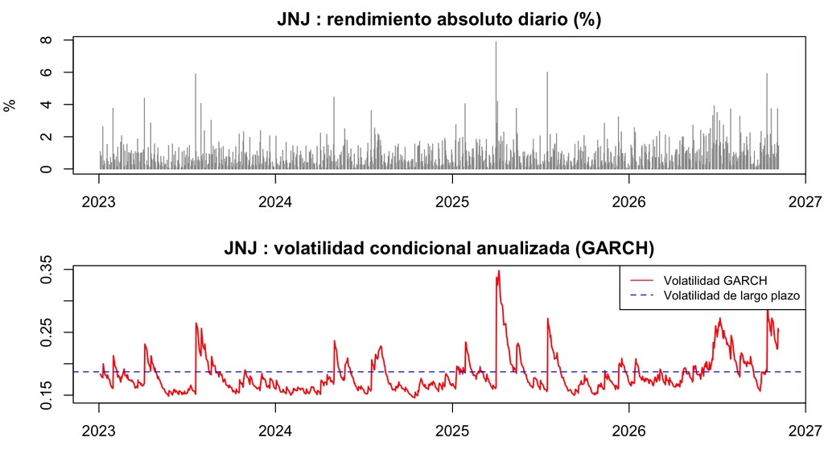

```r
graficar_vol("JNJ")
```

**Interpretación:** Persistencia de 0.94 con vida media de 11 días, similar a NVDA, pero con volatilidad mucho menor: 25% actual contra 19% de largo plazo. Su rendimiento medio no es significativo (p = 0.13), y sus grados de libertad (4.3) indican colas pesadas asociadas a eventos propios de la empresa, como el litigio de talco. Es la segunda acción con menor volatilidad pronosticada (23.4%), lo que confirma su papel como estabilizador del portafolio.

### 5.6.3 WMT

```r
ajustes[["WMT"]]@fit$matcoef
```

```
##          Estimate  Std. Error    t value      Pr(>|t|)
## mu     0.12679363 0.033006723   3.841449 0.00012231032
## omega  0.01806712 0.008799976   2.053088 0.04006404921
## alpha1 0.03128264 0.007101909   4.404821 0.00001058714
## beta1  0.95879046 0.008031993 119.371431 0.00000000000
## shape  3.98406329 0.466860280   8.533738 0.00000000000
```

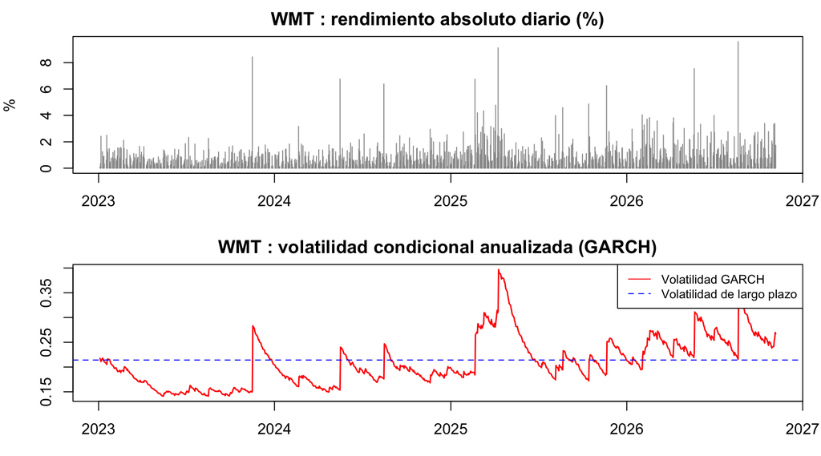

```r
graficar_vol("WMT")
```

## 5.7 Estrategia de portafolio: paridad de riesgo

**Idea:** en la Parte 2 se concluyó que la volatilidad no predice el rendimiento, pero sí mide el riesgo. Por eso se asigna a cada acción un peso **inversamente proporcional a su volatilidad pronosticada por el GARCH**, para que todas aporten un riesgo parecido y ninguna domine el portafolio. Ninguna acción puede superar el 20% del portafolio invertido; el excedente se reparte entre las demás.

```r
vol_pron <- setNames(tabla_garch$Vol_pron_10d, tabla_garch$Accion)

paridad_riesgo <- function(vol, tope) {
  w <- (1 / vol) / sum(1 / vol)
  repeat {
    excede <- w > tope + 1e-12
    if (!any(excede)) break
    sobrante <- sum(w[excede] - tope)
    w[excede] <- tope
    libres <- !excede & w < tope
    w[libres] <- w[libres] + sobrante * w[libres] / sum(w[libres])
  }
  w
}
pesos <- paridad_riesgo(vol_pron, peso_maximo)

kable(data.frame(Accion = names(pesos),
                 Vol_pronosticada = vol_pron[names(pesos)],
                 Peso_objetivo = paste0(round(100 * pesos, 1), "%")),
      row.names = FALSE, caption = "Pesos objetivo por paridad de riesgo (tope 20%)")
```

Pesos objetivo por paridad de riesgo (tope 20%)

| Accion | Vol_pronosticada | Peso_objetivo |
| --- | --- | --- |
| NVDA | 0.533 | 6.1% |
| MSFT | 0.345 | 9.4% |
| AAPL | 0.272 | 11.9% |
| AVGO | 0.591 | 5.5% |
| AMD | 0.833 | 3.9% |
| JPM | 0.276 | 11.7% |
| WMT | 0.266 | 12.2% |
| XOM | 0.286 | 11.3% |
| V | 0.226 | 14.3% |
| JNJ | 0.234 | 13.8% |

### 5.7.1 Portafolio actual vs. propuesto

Se compara el riesgo de ambos portafolios usando:

- **Volatilidad:** con las volatilidades pronosticadas por el GARCH y las correlaciones históricas entre acciones.
- **Beta del portafolio:** promedio ponderado de las betas de cada acción frente al S&P 500.
- **VaR a 1 día al 95%:** pérdida que, en condiciones normales, solo se superaría 1 de cada 20 días. Se calcula con aproximación normal; como hay colas pesadas, es una estimación conservadoramente baja del riesgo extremo.

Se muestran dos niveles: el riesgo de la **parte invertida en acciones** y el del **portafolio total** (incluyendo el efectivo, que no tiene riesgo de mercado).

```r
correl <- cor(rend)
betas  <- sapply(acciones, function(s) {
  d <- na.omit(merge(rend[, s], rend_sp))
  cov(d[, 1], d[, 2]) / var(d[, 2])
})

medir <- function(w_acciones, pct_acciones) {
  v   <- vol_pron[acciones]
  cov_a <- diag(v) %*% correl %*% diag(v)
  vol_a <- sqrt(as.numeric(t(w_acciones) %*% cov_a %*% w_acciones))
  vol_t <- vol_a * pct_acciones
  c(Pct_en_acciones     = round(100 * pct_acciones, 1),
    Vol_anual_acciones  = round(100 * vol_a, 1),
    Vol_anual_total     = round(100 * vol_t, 1),
    Beta_acciones       = round(sum(w_acciones * betas), 2),
    Beta_total          = round(sum(w_acciones * betas) * pct_acciones, 2),
    VaR95_1dia_USD      = round(1.645 * vol_t / sqrt(252) * valor_portafolio, 0))
}

valor_actual <- posiciones[acciones] * cierres[acciones]
w_actual     <- valor_actual / sum(valor_actual)
pct_actual   <- sum(valor_actual) / valor_portafolio

comp <- rbind(Actual    = medir(w_actual, pct_actual),
              Propuesto = medir(pesos[acciones], pct_invertir))
kable(t(comp), caption = "Riesgo del portafolio actual vs. propuesto (volatilidades en % anual)")
```

Riesgo del portafolio actual vs. propuesto (volatilidades en % anual)

|  | Actual | Propuesto |
| --- | --- | --- |
| Pct_en_acciones | 7.20 | 90.00 |
| Vol_anual_acciones | 22.10 | 16.60 |
| Vol_anual_total | 1.60 | 14.90 |
| Beta_acciones | 0.99 | 0.83 |
| Beta_total | 0.07 | 0.75 |
| VaR95_1dia_USD | 1650.00 | 15417.00 |

**Interpretación:** Dentro de la parte invertida, el portafolio propuesto es menos riesgoso que el actual: volatilidad de 16.6% contra 22.1% anual y beta de 0.83 contra 0.99. Sin embargo, como pasa de tener 7.2% del capital en acciones a 90%, su riesgo total sube de 1.6% a 14.9% anual, similar al del S&P 500. El VaR a un día al 95% pasa de 1,650 a 15,417 USD: en un día normal la pérdida no debería superar 1.5% del portafolio, pero en días extremos podría ser mayor por las colas pesadas. Es el costo de poner a trabajar el capital que estaba en efectivo.

### 5.7.2 Plan de operaciones en HowMarketsWorks

Monto a invertir en acciones: **898,771 USD** (90% del valor del portafolio). Precios de referencia: cierre del 6 de noviembre de 2026. El número de acciones se redondea hacia abajo.

```r
objetivo_usd <- valor_portafolio * pct_invertir * pesos[acciones]
objetivo_acc <- floor(objetivo_usd / cierres[acciones])
diferencia   <- objetivo_acc - posiciones[acciones]

plan <- data.frame(
  Accion         = acciones,
  Precio         = round(cierres[acciones], 2),
  Peso_objetivo  = paste0(round(100 * pesos[acciones], 1), "%"),
  Acciones_hoy   = posiciones[acciones],
  Acciones_meta  = objetivo_acc,
  Operacion      = ifelse(diferencia > 0, "Comprar",
                          ifelse(diferencia < 0, "Vender", "Mantener")),
  Cantidad       = abs(diferencia),
  Monto_USD      = round(abs(diferencia) * cierres[acciones], 0)
)
kable(plan, row.names = FALSE, caption = "Operaciones para llegar al portafolio objetivo")
```

Operaciones para llegar al portafolio objetivo

| Accion | Precio | Peso_objetivo | Acciones_hoy | Acciones_meta | Operacion | Cantidad | Monto_USD |
| --- | --- | --- | --- | --- | --- | --- | --- |
| NVDA | 186.64 | 6.1% | 60 | 292 | Comprar | 232 | 43300 |
| MSFT | 530.61 | 9.4% | 50 | 158 | Comprar | 108 | 57306 |
| AAPL | 342.37 | 11.9% | 0 | 312 | Comprar | 312 | 106819 |
| AVGO | 293.69 | 5.5% | 0 | 167 | Comprar | 167 | 49046 |
| AMD | 449.04 | 3.9% | 0 | 77 | Comprar | 77 | 34576 |
| JPM | 334.49 | 11.7% | 41 | 314 | Comprar | 273 | 91316 |
| WMT | 125.52 | 12.2% | 163 | 870 | Comprar | 707 | 88743 |
| XOM | 165.87 | 11.3% | 0 | 612 | Comprar | 612 | 101512 |
| V | 422.65 | 14.3% | 0 | 304 | Comprar | 304 | 128486 |
| JNJ | 276.22 | 13.8% | 0 | 449 | Comprar | 449 | 124023 |

```r
n_ops     <- sum(diferencia != 0)
flujo     <- -sum(diferencia * cierres[acciones]) - n_ops * comision
cat("Número de operaciones:", n_ops, "| Comisiones:", n_ops * comision, "USD\n")
```

```
## Número de operaciones: 10 | Comisiones: 100 USD
```

```r
cat("Cambio neto en efectivo (después de comisiones):", round(flujo, 0), "USD\n")
```

```
## Cambio neto en efectivo (después de comisiones): -825227 USD
```

**Interpretación:** Se requieren 10 compras por un total aproximado de 825,227 USD, más 100 USD de comisiones, con lo que quedarían alrededor de 101,500 USD en efectivo (10% del portafolio). Todas las posiciones existentes aumentan, incluida NVDA (de 60 a 292 acciones): aunque su peso baja a 6.1%, el monto invertido en ella crece porque el portafolio invertido pasa de 72 mil a casi 900 mil USD. Los precios usados son los del cierre del 6 de noviembre, así que las cantidades pueden ajustarse ligeramente al ejecutar.

## 5.8 Conclusión de la estrategia

La estrategia integra los hallazgos de todo el proyecto: los precios no son predecibles en el corto plazo (Parte 3) y la volatilidad no anticipa el rendimiento (Parte 2), pero el riesgo sí es medible y cambia en el tiempo (Parte 4). Por eso los pesos se asignan según el riesgo pronosticado por GARCH y no según expectativas de rendimiento. El portafolio resultante está diversificado en 10 acciones de 5 sectores, con beta de 0.75 sobre el total y una volatilidad similar a la del mercado. Como mejora, se recomienda rebalancear periódicamente con nuevos pronósticos de volatilidad y, dado que la volatilidad está elevada tras el choque del 5 de noviembre, considerar ejecutar las compras de forma escalonada.

**Limitación:** los modelos GARCH de V y AMD tienen persistencia cercana a 1 (0.999) y, en el caso de V, sus residuales conservan dinámica de volatilidad no capturada (Ljung-Box p = 0.000). Su volatilidad pronosticada puede estar subestimada, lo que implica que el peso de V (el mayor del portafolio, 14.3%) podría ser más alto de lo que justificaría su riesgo real. Una extensión natural sería estimar modelos asimétricos (GJR-GARCH o EGARCH) para estas acciones.

# 6 Conclusiones generales

1. **El mercado es el principal motor del rendimiento, pero no por igual.** El modelo de mercado muestra tres perfiles: semiconductores con beta cercana o superior a 2 (AMD, NVDA, AVGO), acciones con beta cercana a 1 (AAPL, MSFT, JPM) y acciones defensivas con beta baja o no significativa (WMT, XOM, JNJ). La regresión múltiple agrega que las tasas de interés importan por sector: favorecen a JPM y XOM y perjudican a JNJ, que se comporta como un bono.
2. **El riesgo explica diferencias entre acciones, no cambios en el tiempo.** El panel trimestral muestra que las acciones más volátiles rindieron más en el periodo, pero que un aumento de volatilidad en una acción no anticipa mayor rendimiento después. Este resultado depende en parte del rally de inteligencia artificial de 2023–2024.
3. **Los precios intradía son prácticamente impredecibles.** Los precios son integrados de orden 1 y la mayoría de los modelos ARIMA resultaron caminatas aleatorias. Cuando el ARIMA superó al modelo ingenuo, lo hizo por márgenes de 1 a 5%, insuficientes para operar con ganancia. Esto es consistente con la eficiencia de mercado en su forma débil.
4. **La volatilidad sí es predecible y cambia en el tiempo.** Los GARCH(1,1) con distribución t-Student muestran parámetros significativos en las 10 acciones, colas pesadas y alta persistencia. Tras el choque del 5 de noviembre de 2026, la volatilidad de casi todas las acciones está por encima de su nivel de largo plazo.
5. **Implicación para la estrategia.** Como el rendimiento no se puede predecir pero el riesgo sí se puede medir, el portafolio se construyó por paridad de riesgo: cada acción pesa en proporción inversa a su volatilidad pronosticada. El resultado es un portafolio de 10 acciones y 5 sectores, con 90% del capital invertido, beta total de 0.75 y una volatilidad similar a la del mercado, con mayor peso en acciones defensivas que el portafolio original.

**Limitaciones y siguientes pasos:** el periodo analizado está dominado por el auge de la inteligencia artificial; los modelos GARCH de V y AMD tienen persistencia cercana a 1; las barras intradía se trataron como consecutivas pese a los saltos entre sesiones, y el VaR se calculó con aproximación normal. Como extensiones se proponen modelos GARCH asimétricos (GJR o EGARCH), un VaR con distribución t-Student y rebalanceos periódicos del portafolio con nuevos pronósticos de volatilidad.

# 7 Evidencia de operaciones en HowMarketsWorks

**Usuario:** luna2707 · **Capital inicial:** 1,000,000 USD

## 7.1 Situación antes de la estrategia (7 de noviembre de 2026)

Antes de aplicar la estrategia, el portafolio tenía solo 4 acciones (MSFT, WMT, NVDA y JPM) y 71,938 USD invertidos, es decir, 7.2% del capital; el resto estaba en efectivo. Su rendimiento (−0.14%) superaba al del SPY (−4.90%), pero principalmente porque la mayor parte del capital no estuvo expuesta a la caída del mercado, no por la selección de acciones. En octubre se había rotado parte de NVDA, JPM y AAPL hacia WMT y después se incorporó MSFT.

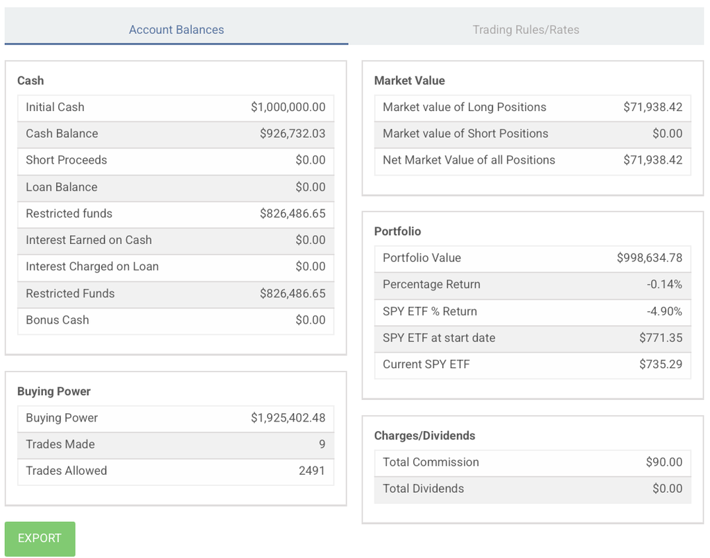

Saldo de la cuenta antes de la estrategia (7-nov-2026)

## 7.2 Órdenes de la estrategia (7 de noviembre de 2026)

Con base en el plan de paridad de riesgo de la Parte 4 se colocaron 10 órdenes de compra a mercado. Como el mercado estaba cerrado, el simulador las dejó pendientes y apartó 826,487 USD como fondos restringidos para cubrirlas.

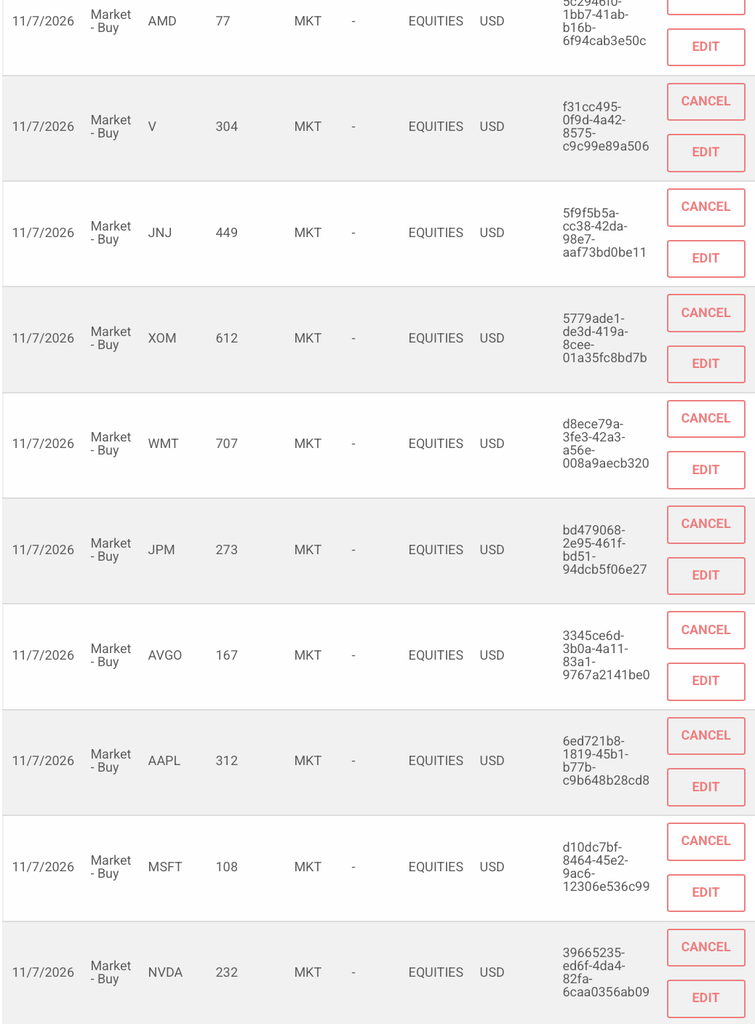

Órdenes de compra colocadas (7-nov-2026)

## 7.3 Ejecución y portafolio final (9 de noviembre de 2026)

Las 10 órdenes se ejecutaron el 9 de noviembre con las cantidades exactas del plan. El monto total de las compras fue de 830,239 USD, 0.6% más que lo estimado con los precios del 6 de noviembre (825,227 USD), porque algunos precios subieron antes de la apertura; el caso más notable fue AMD, que pasó de 449.04 a 473.54 USD (+5.5%). Con 100 USD de comisiones, el efectivo restante quedó en alrededor de 96,400 USD, y el valor invertido en acciones en alrededor de 900,000 USD, el 90% del portafolio definido en la estrategia.

El mismo día de la ejecución, NVDA cayó alrededor de 7%. Como su peso en el portafolio es de 5.6%, el impacto en el valor total fue menor a medio punto porcentual. Este es precisamente el objetivo de la paridad de riesgo: limitar el efecto de las acciones más volátiles.

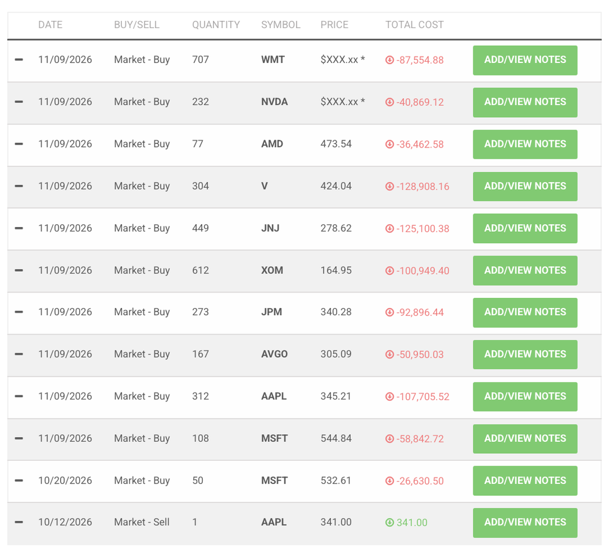

Historial de transacciones, página 1: compras ejecutadas el 9-nov-2026

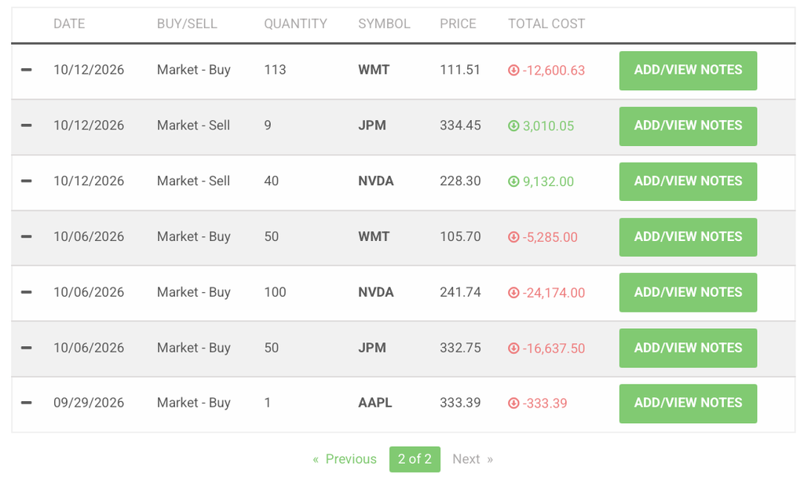

Historial de transacciones, página 2: operaciones previas (septiembre–octubre 2026)

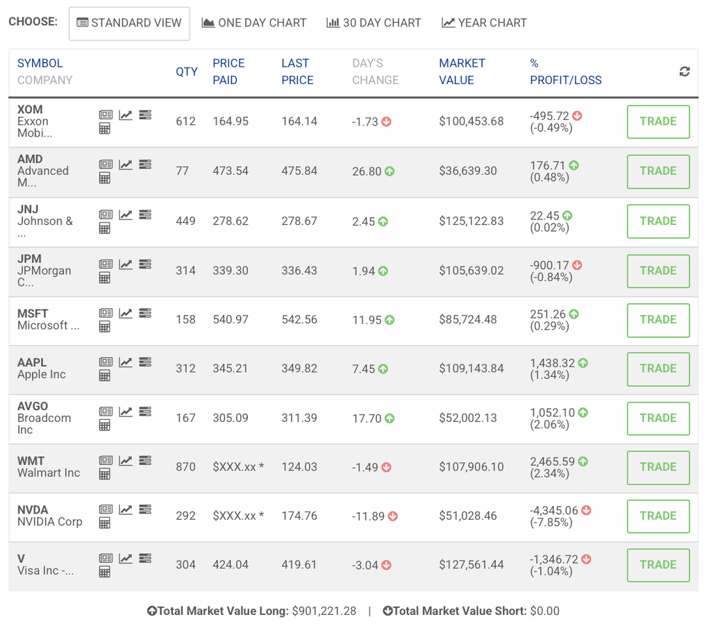

Portafolio final con las 10 acciones (9-nov-2026)

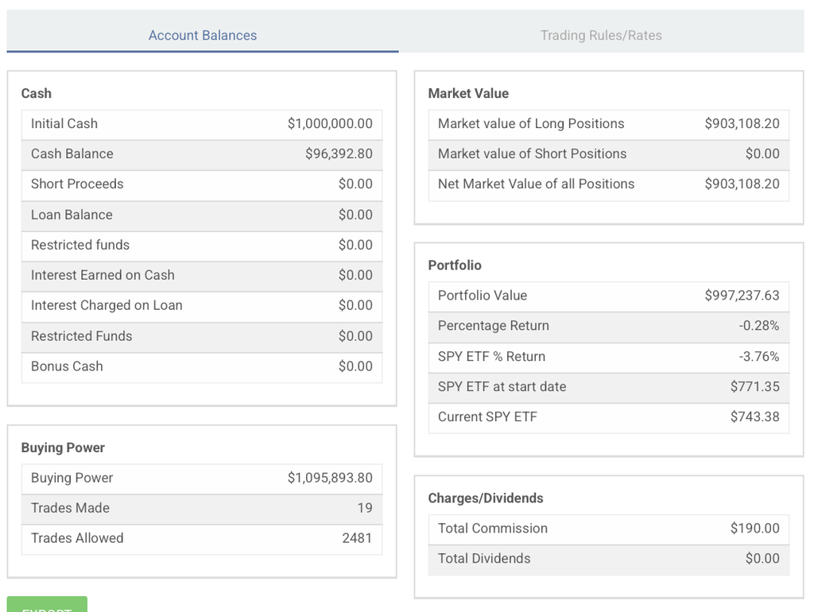

Saldo de la cuenta después de la estrategia (9-nov-2026)

# 8 Anexos

## 8.1 Repositorio y archivos

- **Repositorio de GitHub:** https://github.com/a01162616-sys/Econometr-a/tree/main/Proyecto_Final
- **Carpeta de Google Drive:** https://drive.google.com/drive/folders/1eeCl0Wk0JKnQPLJwl1gBRltxGLMMgLxc?usp=share_link
- **Conversación con GitHub Copilot:** https://github.com/copilot/share/c87a5038-4084-8651-a953-1447840d6857

**Prompt utilizado en GitHub Copilot:**

> Actúa como revisor de código R especializado en econometría financiera. En el repositorio a01162616-sys/Econometr-a, carpeta Proyecto_Final, está el archivo Proyecto_Final_Econometria_Natali_Maya_1.Rmd. Es un proyecto que analiza 10 acciones de EE.UU. (NVDA, MSFT, AAPL, AVGO, AMD, JPM, WMT, XOM, V y JNJ) con regresión lineal simple y múltiple, datos panel trimestrales, modelos ARIMA con forecast intradía (1 hora y 5 minutos) y modelos GARCH(1,1) para construir un portafolio por paridad de riesgo. Por favor: 1) Resume la estructura del proyecto y qué hace cada parte del código. 2) Revisa si el código es reproducible y señala posibles errores, riesgos o mejoras. 3) Genera un archivo README.md en español para la carpeta Proyecto_Final.

**Uso de Copilot en el proyecto:** Copilot generó el README del repositorio y revisó la reproducibilidad del código. A partir de su revisión se incorporó el guardado de los datos diarios en `precios_diarios_guardados.rds`, para que los resultados no cambien cuando Yahoo Finance recalcula precios ajustados por dividendos.